# Project 4

Debug-Thugz

2022-10-02

# Introduction

The project sets out to assess the morphological and allometric differences between different ecomorphs within the genus *Anolis*. A recent study by Hagey et al. (2017) analyzed the hindlimb-ecomorph relationship in anoles. So, this project will determine if ecomorph is an important predictor of the hindlimb-SVL (snout-vent length) relationship in anoles by using phylogenetic least squares analysis to assess this relationship under Brownian motion and OU models of trait evolution.

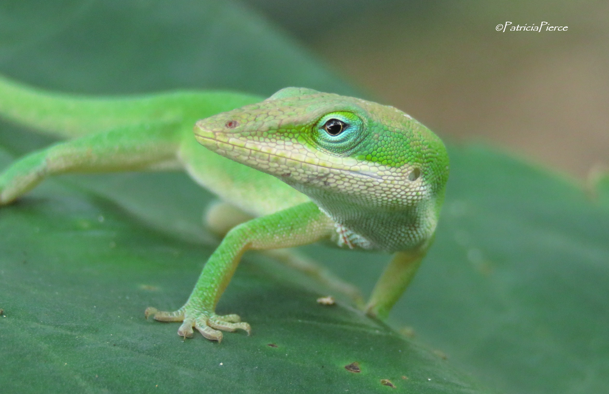

An *Anolis* lizard

# Methods

Using data from an allometry and ecomorphology study of anoles by Hagey et al. (2017) and a different study of anole phylogenetic relationships by Poe et al. (2017), we created statistical models to measure the relationships between hindlimb length and overall body size, in relation with the varying factor of ecomorph, and covaried with phylogenetic position. We specifically collected Akaike Information Criterion (AIC) data to see what the best fit model to the data was with as few parameters as possible. For phylogenetic importance, we utilized phylogenetic generalized least squares (PGLS) tests to see what model best fits the data.

# Results

We found that ecomorph does have an effect on the hindlimb length to SVL relationship for anoles. After conducting PGLS tests and comparing the varying models’ AIC values, it was found that the Brownian motion model with Ecomorph is the best model for the data set provided. The residuals of the data to this PGLS model were plotted for visual analysis of the various parameters that affect these allometric relationships.

The AIC values for PGLS model fit, using either Brownian motion (BM) and Ornstein-Uhlenbeck (OU) models with and without ecomorph influence

| model | Ecomorph | fit | delta | w |
| --- | --- | --- | --- | --- |
| Brownian motion | No | -63.66118 | 29.319176 | 0.0000004 |
| Brownian motion | Yes | -92.98036 | 0.000000 | 0.9827289 |
| Ornstein-Uhlenbeck | No | -57.31864 | 35.661714 | 0.0000000 |
| Ornstein-Uhlenbeck | Yes | -84.89770 | 8.082653 | 0.0172706 |

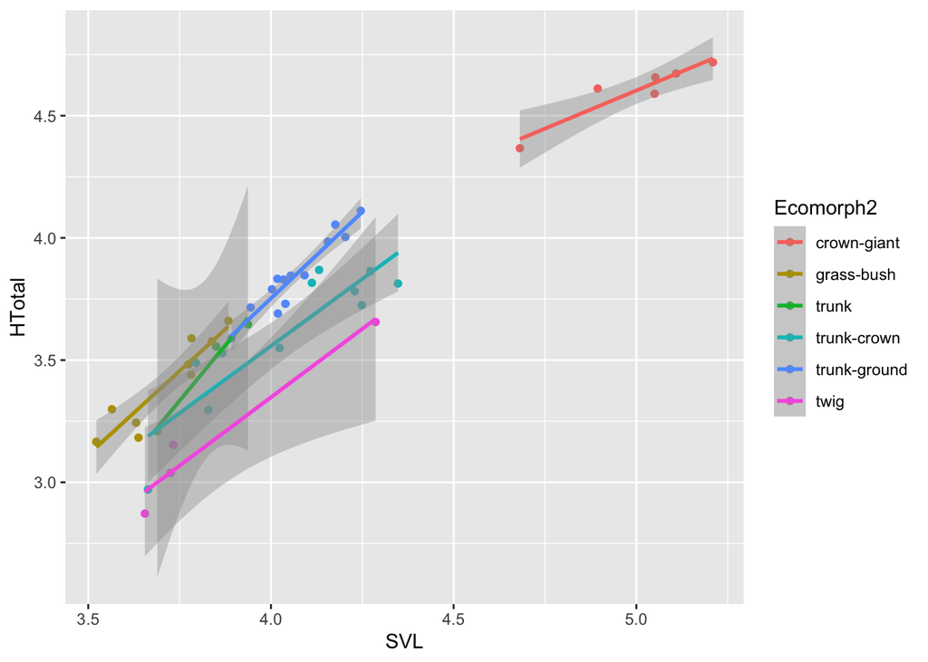

Regression plot of log transformed hindlimb length vs. size values in accordance with specimen ecomorph

The plot above displays a relationship present between the factor of ecomorph and the hindlimb length vs. size allometric relationship of anoles. This points ecomorph being a predictor of this relationship.

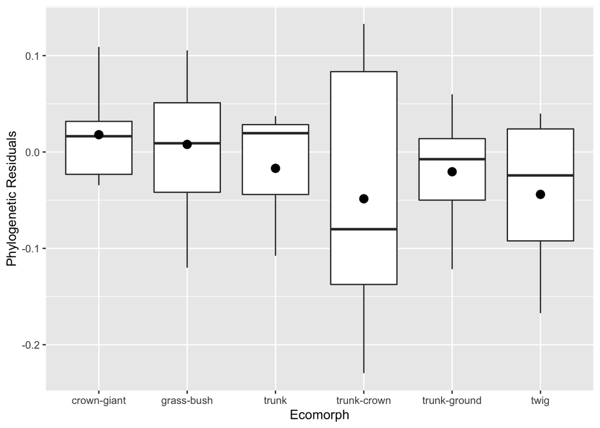

Boxplot of phylogenetically corrected hindlimb residuals versus anole ecomorph

The phylogenetically corrected residuals of the data emphasize the relationship present between ecomorph and this allometric relationship, in addition to the need for phylogenetic consideration of species when understanding these relationships.

# Discussion

The results of the AIC analysis display that the best fit model for the *Anolis* hindlimb v. size data set, with phylogenetic consideration, is a Brownian-Motion model taking varying ecomorphs into account. Studying morphological and allometric differences between ecomorphs and the overall allometric relationships that exist among these specimen is important in order to get an understanding as to why these organisms have evolved to where they are and how they interact with the environment and other species around them. This small data set is a good start in the analysis of the *Anolis* genus, and a strong introduction to the usage of best fit models for data analysis.

# Author Contributions

Project report written up by : Laura Ellis, Elisa Falanga, Tori Newton, and Julie Vu

# References

Hagey, Travis J, Scott Harte, Mathew Vickers, Luke J Harmon, and Lin Schwarzkopf. 2017. “There’s More Than One Way to Climb a Tree: Limb Length and Microhabitat Use in Lizards with Toe Pads.” *PloS One* 12 (9): e0184641.

Poe, Steven, Adrian Nieto-Montes de Oca, Omar Torres-Carvajal, Kevin De Queiroz, Julián A Velasco, Brad Truett, Levi N Gray, et al. 2017. “A Phylogenetic, Biogeographic, and Taxonomic Study of All Extant Species of Anolis (Squamata; Iguanidae).” *Systematic Biology* 66 (5): 663–97.